# R Short Course, Part 4

[R Short Course](https://github.com/jbhender/CSCAR_Workshops/tree/main/rsc/)

## Recommended Reading

- The `stringr` [readme](https://github.com/tidyverse/stringr).
- [Strings](http://r4ds.had.co.nz/strings.html) (Chapter 14) and [Factors](https://r4ds.had.co.nz/factors.html) from Hadley Wickham’s *R for Data Science*.
- An interactive [tutorial](https://regexone.com/lesson/introduction_abcs) on regular expressions.

## Working with Strings in R

In R, you create strings of type `character` using either single or double quotes. There is no difference (in R) between the two.

```r
string1 = "This is a string."
string2 = 'This is a string.'
all.equal(string1, string2)
```

```
## [1] TRUE
```

```r
typeof(string1)
```

```
## [1] "character"
```

This is not the case in all languages.

You can mix single and double quotes when you want to include one or the other within your string.

```r
string_single = "These are sometimes called 'scare quotes'."
print(string_single)
```

```
## [1] "These are sometimes called 'scare quotes'."
```

```r
string_double = 'Quoth the Raven, "Nevermore."'
print(string_double)
```

```
## [1] "Quoth the Raven, \"Nevermore.\""
```

```r
cat(string_double,'\n')
```

```
## Quoth the Raven, "Nevermore."
```

You can also include quotes within a string by escaping them:

```r
string_double = "Quoth the Raven, \"Nevermore.\""
print(string_double)
```

```
## [1] "Quoth the Raven, \"Nevermore.\""
```

```r
cat(string_double,'\n')
```

```
## Quoth the Raven, "Nevermore."
```

Observe the difference between `print()` and `cat()` in terms of how the escaped characters are handled. Be aware also that, because backslash plays this special role as an escape character, it itself needs to be escaped:

```r
backslash = "This is a backslash '\\', this is not '\ '."
writeLines(backslash)
```

```
## This is a backslash '\', this is not ' '.
```

### Files as templates

Similar to `cat()` is the function `writeLines()` used above. The latter is more syntactic when writing to a file and has the advantage of adding a line between components of a vector. Below is an example.

```r
some_file = c('Line 1', 'Line 2')
writeLines(some_file)
```

```
## Line 1
## Line 2
```

```r
## compare to cat
cat(some_file)
```

```
## Line 1 Line 2
```

You should also make note of `readLines()` for reading the text in a file. It is helpful to realize that `readLines()` and `writeLines()` are inverse to one another.

### String operations

The table below collects some common string operations from base R and their parallels in the `stringr` package. I say *parallels* and not *equivalents* because they do not always behave in the same way. If you are new to string manipulation in R, I suggest you use `stringr` for these operations. However, you should be aware of the common base functions as you may encounter them in code written by others.

| operation | base | stringr |
| --- | --- | --- |
| join | `paste` | `str_c` |
| subset | `substr` | `str_sub` |
| split | `strsplit` | `str_split` |
| search | `grep`, `grepl` | `str_which`,`str_detect` |

#### concatenating strings

The functions `paste` and `stringr::str_c` are both used to join strings together.

Observe the difference between the `sep` and `collapse` arguments in `paste`.

```r
length(LETTERS)
```

```
## [1] 26
```

```r
paste(LETTERS, collapse = "")
```

```
## [1] "ABCDEFGHIJKLMNOPQRSTUVWXYZ"
```

```r
paste(1:26, LETTERS, sep = ': ')
```

```
##  [1] "1: A"  "2: B"  "3: C"  "4: D"  "5: E"  "6: F"  "7: G"  "8: H"  "9: I"
## [10] "10: J" "11: K" "12: L" "13: M" "14: N" "15: O" "16: P" "17: Q" "18: R"
## [19] "19: S" "20: T" "21: U" "22: V" "23: W" "24: X" "25: Y" "26: Z"
```

```r
paste(1:26, LETTERS, sep = ': ', collapse = '\n ')
```

```
## [1] "1: A\n 2: B\n 3: C\n 4: D\n 5: E\n 6: F\n 7: G\n 8: H\n 9: I\n 10: J\n 11: K\n 12: L\n 13: M\n 14: N\n 15: O\n 16: P\n 17: Q\n 18: R\n 19: S\n 20: T\n 21: U\n 22: V\n 23: W\n 24: X\n 25: Y\n 26: Z"
```

Below we see that `str_c` behaves similarly.

```r
library(stringr) # stringr is in the tidyverse
all.equal(str_c(LETTERS, collapse = ""), paste(LETTERS, collapse = ""))
```

```
## [1] TRUE
```

```r
all.equal(str_c(1:26, LETTERS, sep = ': '), paste(1:26, LETTERS, sep = ': '))
```

```
## [1] TRUE
```

```r
all.equal(
  str_c(1:26, LETTERS, sep = ': ', collapse = '\n '),
  paste(1:26, LETTERS, sep = ': ', collapse = '\n ')
)
```

```
## [1] TRUE
```

However, these functions differ in the treatment of missing values (`NA`).

```r
paste(1:3, c(1, NA, 3), sep = ':', collapse = ', ')
```

```
## [1] "1:1, 2:NA, 3:3"
```

```r
str_c(1:3, c(1, NA, 3), sep = ':', collapse = ', ')
```

```
## [1] NA
```

```r
str_c(1:3, str_replace_na(c(1, NA, 3)), sep = ":", collapse = ', ')
```

```
## [1] "1:1, 2:NA, 3:3"
```

#### length

Recall that `length` returns the length of a vector. To get the length of a string use `nchar` or `str_length`.

```r
length(paste(LETTERS, collapse = "") )
```

```
## [1] 1
```

```r
nchar(paste(LETTERS, collapse = "") )
```

```
## [1] 26
```

```r
str_length(paste(LETTERS, collapse = "") )
```

```
## [1] 26
```

#### substrings

The following functions extract sub-strings at given positions.

```r
substr('Strings',  3, 7)
```

```
## [1] "rings"
```

```r
str_sub('Strings', 1, 6)
```

```
## [1] "String"
```

The function `stringr::str_sub` supports negative indexing.

```r
sprintf('base: %s, stringr: %s',
        substr('Strings', -5, -1),
        str_sub('Strings', -5, -1)
)
```

```
## [1] "base: , stringr: rings"
```

#### finding matches

The example below uses the vector `fruit` from the `stringr` package.

The base function `grep` returns the indices of all strings within a vector that contain the requested pattern. The `grepl` function behaves in the same way but returns a logical vector of the same length as the input `x`.

```r
head(fruit)
```

```
## [1] "apple"       "apricot"     "avocado"     "banana"      "bell pepper"
## [6] "bilberry"
```

```r
grep('fruit', fruit)
```

```
## [1] 12 26 35 39 42 57 75 79
```

```r
which(grepl('fruit', fruit) )
```

```
## [1] 12 26 35 39 42 57 75 79
```

```r
head(grepl('fruit', fruit) )
```

```
## [1] FALSE FALSE FALSE FALSE FALSE FALSE
```

```r
grepl('fruit', fruit)[grep('fruit', fruit)]
```

```
## [1] TRUE TRUE TRUE TRUE TRUE TRUE TRUE TRUE
```

These functions are vectorized over the input but not the pattern.

```r
grep(c('fruit', 'berry'), fruit)
```

```
## [1] 12 26 35 39 42 57 75 79
```

```r
sapply(c('fruit', 'berry'), grep, x = fruit)
```

```
## $fruit
## [1] 12 26 35 39 42 57 75 79
##
## $berry
##  [1]  6  7 10 11 19 21 29 32 33 38 50 70 73 76
```

The `match` function is vectorized over the input, but returns only the first match and requires exact matching.

```r
match('berry', fruit)
```

```
## [1] NA
```

```r
match(c('apple', 'pear'), c(fruit, fruit))
```

```
## [1]  1 59
```

The corresponding `stringr` functions are vectorized over both pattern and input, but the vectorization uses broadcasting so be careful. Pay attention to the order that the string and pattern are supplied in as it is the reverse of the base functions.

```r
ind_fruit = which(str_detect(fruit, 'fruit') )
ind_berry = which(str_detect(fruit, 'berry') )

ind_either = which(str_detect(fruit, c('fruit','berry') ) )
setdiff(union(ind_fruit, ind_berry), ind_either )
```

```
##  [1] 12 26 42  7 11 19 21 29 33 73
```

```r
# below I demonstrate the broadcasting pattern
ind_odd = seq(1, length(fruit), 2)
ind_even = seq(2, length(fruit), 2)

odd_fruit = ind_odd[ str_detect(fruit[ind_odd], 'fruit') ]
even_berry = ind_even[ str_detect(fruit[ind_even], 'berry') ]
setdiff(union(odd_fruit, even_berry), ind_either )
```

```
## numeric(0)
```

The vectorization in this case doesn’t help us to avoid the `lapply` pattern we used with `grep`.

```r
sapply(c('fruit', 'berry'), function(x) which(str_detect(fruit, x) ) )
```

```
## $fruit
## [1] 12 26 35 39 42 57 75 79
##
## $berry
##  [1]  6  7 10 11 19 21 29 32 33 38 50 70 73 76
```

However, `str_locate` is vectorized using an “OR” operator.

```r
ind_fruit = str_locate(fruit, 'fruit')
ind_berry = str_locate(fruit, 'berry')

ind_either = str_locate(fruit, c('fruit','berry'))
setdiff(union(ind_fruit, ind_berry), ind_either )
```

```
## integer(0)
```

#### find and replace

For find and replace operations, you can use one of `str_replace` or `str_replace_all`. The former matches only the first instance of pattern. Similar base functions are `sub` and `gsub`.

```r
# abc ...
letter_vec = paste(letters, collapse = '')

## replace all instances
str_replace_all(letter_vec, '[aeiou]', 'X')
```

```
## [1] "XbcdXfghXjklmnXpqrstXvwxyz"
```

```r
#replace the first instance
str_replace(letter_vec, '[aeiou]', 'X')
```

```
## [1] "Xbcdefghijklmnopqrstuvwxyz"
```

You can also find and/or replace by the position in a string using `str_sub`.

```r
# to replace by location
str_sub(letter_vec, start = 1:3, end = 2:4)
```

```
## [1] "ab" "bc" "cd"
```

```r
str_sub(letter_vec, start = -3, end = -1) = 'XXX'
```

#### splitting strings

The base function `strsplit` can be used to split a string into pieces based on a pattern. The example below finds all two-word fruit names from `fruit`.

```r
fruit_list = strsplit(fruit,' ')
two_ind = which(sapply(fruit_list, length)==2)
fruit_two = lapply(fruit_list[two_ind], paste, collapse=' ')
unlist(fruit_two)
```

```
##  [1] "bell pepper"       "blood orange"      "canary melon"
##  [4] "chili pepper"      "goji berry"        "kiwi fruit"
##  [7] "purple mangosteen" "rock melon"        "salal berry"
## [10] "star fruit"        "ugli fruit"
```

The `str_split` function behaves similarly for this simple case.

```r
all.equal(fruit_list, str_split(fruit, ' '))
```

```
## [1] TRUE
```

When there are multiple patterns matching the split point, the functions `strsplit` and `str_split` behave differently.

```r
string = '1;2,3'
strsplit(string, c(';', ','))
```

```
## [[1]]
## [1] "1"   "2,3"
```

```r
str_split(string, c(';', ','))
```

```
## [[1]]
## [1] "1"   "2,3"
##
## [[2]]
## [1] "1;2" "3"
```

```r
# Use a regular expression to split on either character.
str_split(string,';|,')
```

```
## [[1]]
## [1] "1" "2" "3"
```

## Regular Expressions

*Regular expressions* (“regexp” or “regex”) are a way to describe patterns in strings, often in an abstract way. There is a common regexp vocabulary though some details differ between implementations and standards. The basic idea is illustrated in the examples below using the fruit data from the `stringr` library.

```r
## find all two word fruits by searching for a space
fruit[grep(" ", fruit)]
```

```
##  [1] "bell pepper"       "blood orange"      "canary melon"
##  [4] "chili pepper"      "goji berry"        "kiwi fruit"
##  [7] "purple mangosteen" "rock melon"        "salal berry"
## [10] "star fruit"        "ugli fruit"
```

```r
## find all fruits with an 'a' anywhere in the word
fruit[grep("a", fruit)]
```

```
##  [1] "apple"             "apricot"           "avocado"
##  [4] "banana"            "blackberry"        "blackcurrant"
##  [7] "blood orange"      "breadfruit"        "canary melon"
## [10] "cantaloupe"        "cherimoya"         "cranberry"
## [13] "currant"           "damson"            "date"
## [16] "dragonfruit"       "durian"            "eggplant"
## [19] "feijoa"            "grape"             "grapefruit"
## [22] "guava"             "jackfruit"         "jambul"
## [25] "kumquat"           "loquat"            "mandarine"
## [28] "mango"             "nectarine"         "orange"
## [31] "pamelo"            "papaya"            "passionfruit"
## [34] "peach"             "pear"              "physalis"
## [37] "pineapple"         "pomegranate"       "purple mangosteen"
## [40] "raisin"            "rambutan"          "raspberry"
## [43] "redcurrant"        "salal berry"       "satsuma"
## [46] "star fruit"        "strawberry"        "tamarillo"
## [49] "tangerine"         "watermelon"
```

```r
## find all fruits starting with 'a'
fruit[grep("^a", fruit)]
```

```
## [1] "apple"   "apricot" "avocado"
```

```r
## find all fruits ending with 'a'
fruit[grep("a$", fruit)]
```

```
## [1] "banana"    "cherimoya" "feijoa"    "guava"     "papaya"    "satsuma"
```

```r
## find all fruits starting with a vowel
fruit[grep("^[aeiou]", fruit)]
```

```
## [1] "apple"      "apricot"    "avocado"    "eggplant"   "elderberry"
## [6] "olive"      "orange"     "ugli fruit"
```

```r
## find all fruits with two consecutive vowels
fruit[grep("[aeiou]{2}", fruit)]
```

```
##  [1] "blood orange"      "blueberry"         "breadfruit"
##  [4] "cantaloupe"        "cloudberry"        "dragonfruit"
##  [7] "durian"            "feijoa"            "gooseberry"
## [10] "grapefruit"        "guava"             "jackfruit"
## [13] "kiwi fruit"        "kumquat"           "loquat"
## [16] "lychee"            "passionfruit"      "peach"
## [19] "pear"              "pineapple"         "purple mangosteen"
## [22] "quince"            "raisin"            "star fruit"
## [25] "ugli fruit"
```

```r
## find all fruits ending with two consecutive consonants other than r
fruit[grep("[^aeiour]{2}$", fruit)]
```

```
## [1] "blackcurrant" "currant"      "eggplant"     "peach"        "redcurrant"
```

In the examples above, we return all strings matching a simple pattern.

We can specify that the pattern be found at the beginning `^a` or end `a$` using *anchors*. We can provide multiple options for the match within brackets `[]`. We can negate options within brackets using `^` in a different context. The curly braces ask for a specific number (or range `{min, max}`) of matches.

In the example below we use `.` to match any (single) character. We can ask for multiple matches by appending `*` if we want 0 or more matches and `+` if we want at least 1 match.

```r
## find all fruits with two consecutive vowels twice, separated by a single
## consonant
fruit[grep("[aeiou]{2}.[aeiou]{2}", fruit)]
```

```
## [1] "feijoa"
```

```r
## find all fruits with two consecutive vowels twice, separated by one or
## more consonants
fruit[grep("[aeiou]{2}.+[aeiou]{2}", fruit)]
```

```
## [1] "breadfruit"   "feijoa"       "passionfruit"
```

```r
## find all fruits with exactly three consecutive consonants in the middle of
## two vowels
fruit[grep("[aeiou][^aeiou ]{3}[aeiou]", fruit)]
```

```
##  [1] "apple"             "blackberry"        "blackcurrant"
##  [4] "breadfruit"        "dragonfruit"       "huckleberry"
##  [7] "passionfruit"      "pineapple"         "purple mangosteen"
## [10] "raspberry"
```

```r
#str_view(fruit, "[aeiou][^aeiou ]{3}[aeiou]")
```

To match an actual period (or other meta-character) we need to escape with a backslash. Thus, we use the regular expression `\\.`

```r
c(fruit, "umich.edu")[grep('\\.', c(fruit, "umich.edu"))]
```

```
## [1] "umich.edu"
```

The double backslash is needed because the regular expression itself is passed as a string and strings also use backslash as an escape character. This is also important to remember when building file paths as strings on a Windows computer. In other languages, you generally only need a single backslash in your regular expression.

Matched values can be grouped using parentheses `()` and referred back to in the order they appear using a back reference `\\1`.

```r
## find all fruits with a repeated letter
fruit[grep("(.)\\1", fruit)]
```

```
##  [1] "apple"             "bell pepper"       "bilberry"
##  [4] "blackberry"        "blackcurrant"      "blood orange"
##  [7] "blueberry"         "boysenberry"       "cherry"
## [10] "chili pepper"      "cloudberry"        "cranberry"
## [13] "currant"           "eggplant"          "elderberry"
## [16] "goji berry"        "gooseberry"        "huckleberry"
## [19] "lychee"            "mulberry"          "passionfruit"
## [22] "persimmon"         "pineapple"         "purple mangosteen"
## [25] "raspberry"         "redcurrant"        "salal berry"
## [28] "strawberry"        "tamarillo"
```

```r
## find all fruits with a repeated letter but exclude double r
fruit[grep("([^r])\\1", fruit)]
```

```
##  [1] "apple"             "bell pepper"       "blood orange"
##  [4] "chili pepper"      "eggplant"          "gooseberry"
##  [7] "lychee"            "passionfruit"      "persimmon"
## [10] "pineapple"         "purple mangosteen" "tamarillo"
```

```r
## find all fruits that end with a repeated letter
fruit[grep("(.)\\1$", fruit)]
```

```
## [1] "lychee"
```

## (Exercise) Regex crosswords

A fun way to learn or brush up on your knowledge of regular expressions is to solve a [Regex Crossword](https://regexcrossword.com/).

## Factors

Factors are a form of S3 vector in R useful for working with categorical variables that take on a fixed set of possible values. We use factors in regression modelling to indicate terms that should be encoded as a set of (usually) orthogonal 0/1 basis functions. Factor are also useful when you want to display string variables on a plotting axis in a non alphabetical order.

Factor vectors are built on top of an atomic integer vectors with a special attribute `levels` providing a unique label for each of the possible values. Moreover, because they have class `factor` R’s S3 method dispatch means they may be treated similarly or differently than integer vectors or character vectors depending on context.

### Creating Factors

Factors are usually created using the construct `factor()`. In the example below, we crate a factor `transmission` from the `am` factor in the built in `mtcars` data.

```r
mtcars[['transmission']] =
  with(mtcars, factor(am, levels = c(0, 1), labels = c('automatic', 'manual')))
```

When using `factor()` the `levels` argument the current set of unique values and the `labels` argument to assign names to these.

```r
class(mtcars[['transmission']])
```

```
## [1] "factor"
```

```r
levels(mtcars[['transmission']])
```

```
## [1] "automatic" "manual"
```

```r
# note the change
as.numeric(mtcars[['transmission']])
```

```
##  [1] 2 2 2 1 1 1 1 1 1 1 1 1 1 1 1 1 1 2 2 2 1 1 1 1 1 2 2 2 2 2 2 2
```

```r
as.character(mtcars[['transmission']])
```

```
##  [1] "manual"    "manual"    "manual"    "automatic" "automatic" "automatic"
##  [7] "automatic" "automatic" "automatic" "automatic" "automatic" "automatic"
## [13] "automatic" "automatic" "automatic" "automatic" "automatic" "manual"
## [19] "manual"    "manual"    "automatic" "automatic" "automatic" "automatic"
## [25] "automatic" "manual"    "manual"    "manual"    "manual"    "manual"
## [31] "manual"    "manual"
```

```r
names(attributes(mtcars[['transmission']]))
```

```
## [1] "levels" "class"
```

```r
attr(mtcars[['transmission']], 'levels')
```

```
## [1] "automatic" "manual"
```

Note that the levels are always numbered from 1 after creating a factor and that the “labels” are now called “levels” and accessed with the accessor function `levels()`.

### Working with factors

Using the factor we get nice labels in, e.g., a table or a ggplot graphic.

```r
with(mtcars, table(transmission, am))
```

```
##             am
## transmission  0  1
##    automatic 19  0
##    manual     0 13
```

In fact, for `ggplot` we must use factor variables for discrete aesthetics.

```r
library(tidyverse)
```

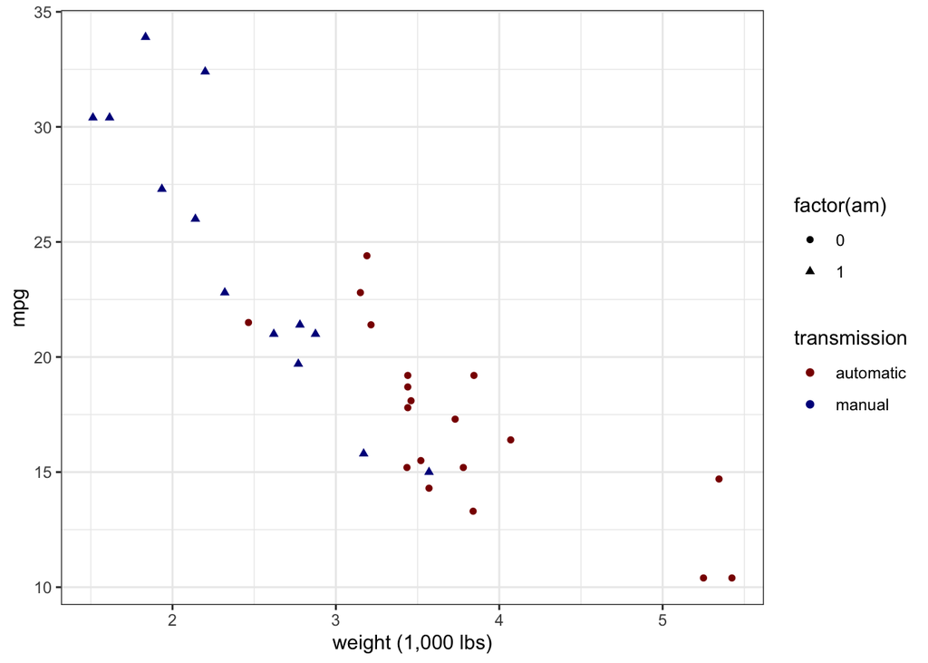

```r
mtcars %>%
  ggplot(aes(x = wt, y = mpg, color = transmission, shape = factor(am))) +
  geom_point() +
  theme_bw() +
  scale_color_manual(values = c('darkred', 'darkblue')) +
  xlab('weight (1,000 lbs)')
```

In the example below, the order of the boxplots is determined by the order of the factor.

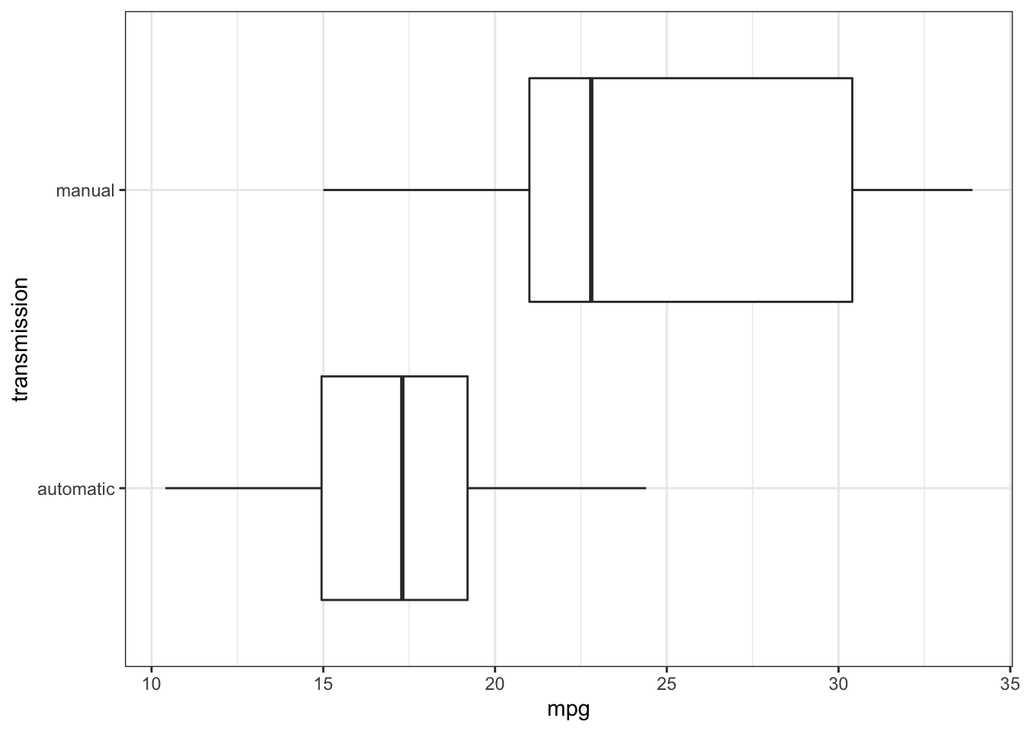

```r
mtcars %>%
  ggplot(aes(x = mpg, y = transmission)) +
  geom_boxplot() +
  theme_bw()
```

We can change the order of a factor in two ways. To choose a new reference level and increment other levels by 1, use `relevel()`. Here we’ll use `dplyr::mutate()` to do this on the fly.

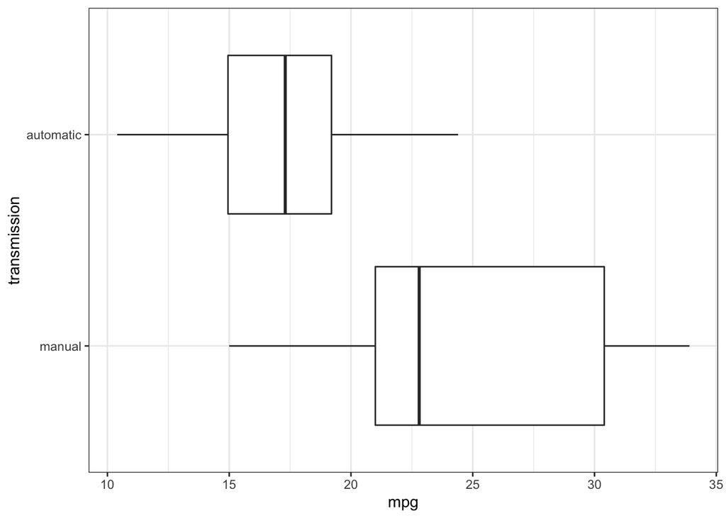

```r
mtcars %>%
  mutate(transmission = relevel(transmission, ref = 'manual')) %>%
  ggplot(aes(x = mpg, y = transmission)) +
  geom_boxplot() +
  theme_bw()
```

When you have more than a few levels and want a totally new order it’s best to create a new factor.

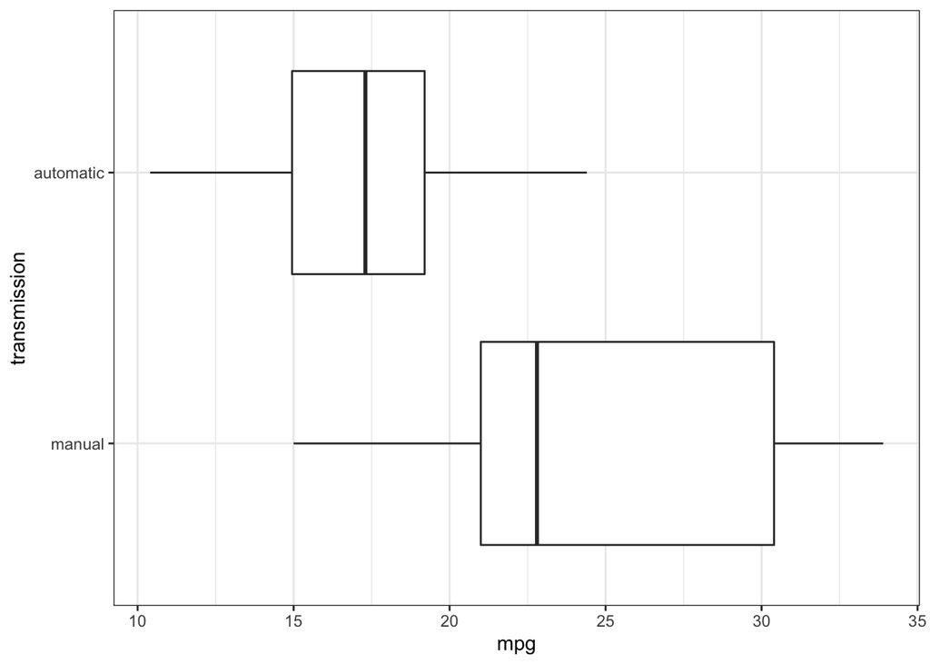

```r
new_ord = c('manual', 'automatic')
stopifnot( all(levels(mtcars[['transmission']]) %in% new_ord))
mtcars %>%
  mutate(transmission = factor(transmission, new_ord, new_ord)) %>%
  ggplot(aes(x = mpg, y = transmission)) +
   geom_boxplot() +
   theme_bw()
```

This can be when you want to order one variable in terms of another.

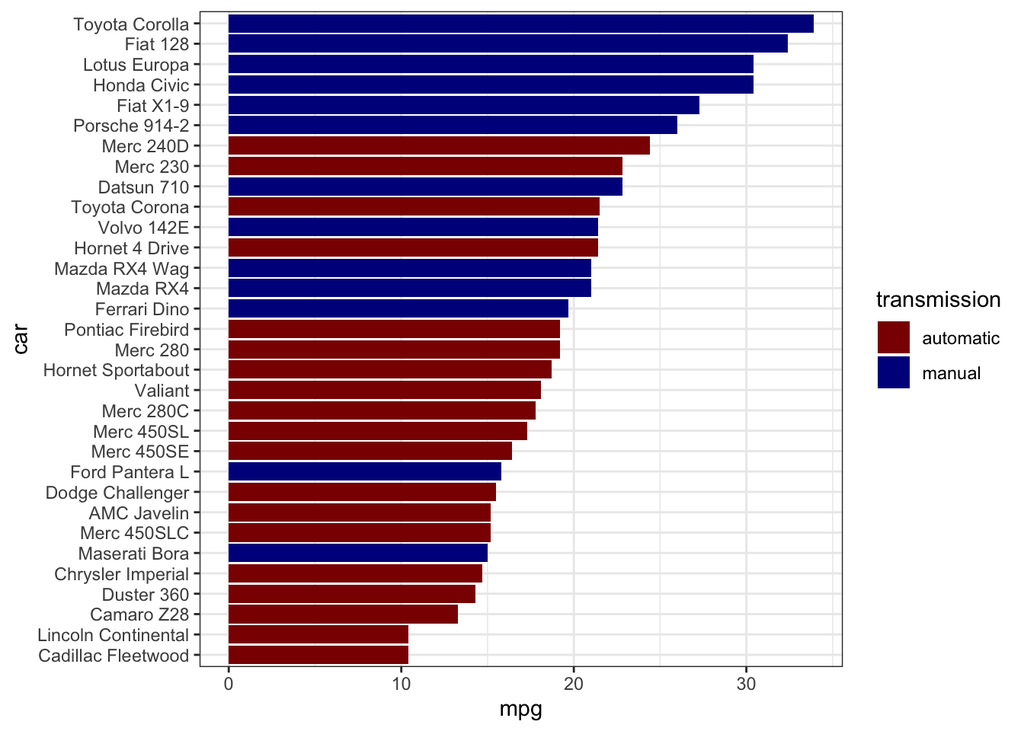

```r
mtcars %>%
  arrange(mpg) %>%
  mutate(car = factor(rownames(.), rownames(.))) %>%
  ggplot(aes(x = car, y = mpg, fill = transmission)) +
   geom_col() +
   coord_flip() +
   scale_fill_manual(values = c('darkred', 'darkblue')) +
   theme_bw()
```

Finally, note the difference in how factors are treated when forming design matrices for regression.

```r
mtcars[['cyl_f']] = with(mtcars, factor(cyl))
x1 = model.matrix(mpg ~ cyl, data = mtcars)
x2 = model.matrix(mpg ~ cyl_f, data = mtcars)

cbind(head(x1), matrix(NA, nrow = 6), head(x2))
```

```
##                   (Intercept) cyl    (Intercept) cyl_f6 cyl_f8
## Mazda RX4                   1   6 NA           1      1      0
## Mazda RX4 Wag               1   6 NA           1      1      0
## Datsun 710                  1   4 NA           1      0      0
## Hornet 4 Drive              1   6 NA           1      1      0
## Hornet Sportabout           1   8 NA           1      0      1
## Valiant                     1   6 NA           1      1      0
```

```r
lm(mpg ~ cyl, data = mtcars) |> summary()
```

```
##
## Call:
## lm(formula = mpg ~ cyl, data = mtcars)
##
## Residuals:
##     Min      1Q  Median      3Q     Max
## -4.9814 -2.1185  0.2217  1.0717  7.5186
##
## Coefficients:
##             Estimate Std. Error t value Pr(>|t|)
## (Intercept)  37.8846     2.0738   18.27  < 2e-16 ***
## cyl          -2.8758     0.3224   -8.92 6.11e-10 ***
## ---
## Signif. codes:  0 '***' 0.001 '**' 0.01 '*' 0.05 '.' 0.1 ' ' 1
##
## Residual standard error: 3.206 on 30 degrees of freedom
## Multiple R-squared:  0.7262, Adjusted R-squared:  0.7171
## F-statistic: 79.56 on 1 and 30 DF,  p-value: 6.113e-10
```

```r
lm(mpg ~ cyl_f, data = mtcars) |> summary()
```

```
##
## Call:
## lm(formula = mpg ~ cyl_f, data = mtcars)
##
## Residuals:
##     Min      1Q  Median      3Q     Max
## -5.2636 -1.8357  0.0286  1.3893  7.2364
##
## Coefficients:
##             Estimate Std. Error t value Pr(>|t|)
## (Intercept)  26.6636     0.9718  27.437  < 2e-16 ***
## cyl_f6       -6.9208     1.5583  -4.441 0.000119 ***
## cyl_f8      -11.5636     1.2986  -8.905 8.57e-10 ***
## ---
## Signif. codes:  0 '***' 0.001 '**' 0.01 '*' 0.05 '.' 0.1 ' ' 1
##
## Residual standard error: 3.223 on 29 degrees of freedom
## Multiple R-squared:  0.7325, Adjusted R-squared:  0.714
## F-statistic:  39.7 on 2 and 29 DF,  p-value: 4.979e-09
```